# Data Science Capstone Milestone Report

Sid M

## Foreword

- I chose to do most of the operations in the OSX command-line terminal because R is extremely slow.
- I made the bigrams, trigrams and tetragrams in R, but they took hours to compute.

## Installation

- First, we download the capstone dataset [here](https://d396qusza40orc.cloudfront.net/dsscapstone/dataset/Coursera-SwiftKey.zip).
- Then, we unzip the dataset and move the files from the **/final/en_US** directory to a new **raw/** directory, which is a subdirectory of where we will be running our commands.
- Finally, we create **processed/**, **training/**, **test/** & **validation/** subdirectories as well.

## Basic Summary

- We enter the **raw/** directory and run the `$ wc` command in the directory containing the en_US data. This gives us:

| lines | words | characters | filename |
| --- | --- | --- | --- |
| 899288 | 37334690 | 210160014 | en_US.blogs.txt |
| 1010242 | 34372720 | 205811889 | en_US.news.txt |
| 2360148 | 30374206 | 167105338 | en_US.twitter.txt |

- We then investigate all the files with the following commands:

  ```
  $ head en_US.twitter.txt
  $ head en_US.blogs.txt
  $ head en_US.news.txt
  ```

- We find out that the files consist of UTF-8 encoded english text from various blogs, news sources and tweets. Each line in all the files correspond a source. There are non-ASCII characters in the text like emojis, chinese characters, etc.
- We have a total of 600 MB of text, which should provide us with enough corpus to develop a natural language processing model. I don’t think we might need additional data sources.

## Cleaning the text (Terminal)

- We keep only a subset of characters that will be useful to us to word prediction. Thus, we remove everything but `a-z`, `A-Z`, `;`, `.`, `space` and `#`. (The reason we keep the `#` is to let us remove twitter hashtags.) We achieve the subset with `sed "s/[^a-zA-Z#;. ]//g"`.
- We will remove all twitter hashtags from the files. This is because twitter hash words are compound words that shouldn’t be used for prediction. We achieve this with `sed 's/#[a-zA-Z]*//g`
- People often have a habit of using multiple periods, and we need to clean that to one period only. We achieve this with `sed 's/\.\.*/\./g'`
- We convert the sentences from mixed case to lower case with `tr '[:upper:]' '[:lower:]'`
- Periods and semicolons essentially start a new sentence, and are the start of a new chain. So, we assign those sentences to a new line. We achieve this with `tr '.;' '\n'`
- We clean up multiple new lines in a row with this: `sed '/^ *$/d'`
- We then clean up sentences that have multiple spaces in them with `sed 's/\ [\ ]*/\ /g'`
- We then clean up sentences that start or end with spaces with `sed 's/^\ //g'` & `sed 's/\ $//g`
- We chain all of the above to give us:

  ```
  $ cat raw/en_US.twitter.txt | sed "s/[^a-zA-Z#;. ]//g" | sed 's/#[a-zA-Z]*//g' | sed 's/\.\.*/\./g' | tr '.;' '\n' | sed '/^ *$/d' | tr '[:upper:]' '[:lower:]' | sed 's/\ [\ ]*/\ /g' | sed 's/^\ //g' | sed 's/\ $//g' > processed/en_US.twitter.txt
  $ cat raw/en_US.news.txt | sed "s/[^a-zA-Z#;. ]//g" | sed 's/#[a-zA-Z]*//g' | sed 's/\.\.*/\./g' | tr '.;' '\n' | sed '/^ *$/d' | tr '[:upper:]' '[:lower:]' | sed 's/\ [\ ]*/\ /g' | sed 's/^\ //g' | sed 's/\ $//g' > processed/en_US.news.txt
  $ cat raw/en_US.blogs.txt | sed "s/[^a-zA-Z#;. ]//g" | sed 's/#[a-zA-Z]*//g' | sed 's/\.\.*/\./g' | tr '.;' '\n' | sed '/^ *$/d' | tr '[:upper:]' '[:lower:]' | sed 's/\ [\ ]*/\ /g' | sed 's/^\ //g' | sed 's/\ $//g' > processed/en_US.blogs.txt
  ```

- Now, we split the various files into training, validation & test sets in a 50:25:25 ratio. We achieve this by running the following in the shell:

  ```
  $ split -l $[ $(wc -l processed/en_US.news.txt |cut -d" " -f2) * 25 / 100 ] processed/en_US.news.txt
  $ cat xaa xab > training/en_US.news.txt
  $ mv xac test/en_US.news.txt
  $ mv xad validation/en_US.news.txt
  $ rm x*
  $ split -l $[ $(wc -l processed/en_US.blogs.txt |cut -d" " -f2) * 25 / 100 ] processed/en_US.blogs.txt
  $ cat xaa xab > training/en_US.blogs.txt
  $ mv xac test/en_US.blogs.txt
  $ mv xad validation/en_US.blogs.txt
  $ rm x*
  $ split -l $[ $(wc -l processed/en_US.twitter.txt |cut -d" " -f2) * 25 / 100 ] processed/en_US.twitter.txt
  $ cat xaa xab > training/en_US.twitter.txt
  $ mv xac test/en_US.twitter.txt
  $ mv xad validation/en_US.twitter.txt
  $ rm x*
  en_US.blogs <- readLines(con = "./final/en_US/en_US.blogs.txt", encoding = "UTF-8")
  ```

- Now, we have cleaned the text and split the corpus into training, test and validation sets.
- We are now ready to be split into mono-grams, bi-grams, tri-grams and quad-grams.
- I choose not to remove “bad” or “swear” words because I believe them to be legitimate words that have meaning and reason. Imagine how much weaker the movie Pulp Fiction would be if Samuel L. Jackson wasn’t allowed to cuss.
- I choose not to remove stopwords because I believe they are the glue of english language and will help us predict upcoming words.

## Modelling (R)

- Ensure you have the following libraries available in R: **Rweka**, **tm**
- We load the corpus and tokenise it in Bi-grams, Tri-grams and Quadra-grams in the following step. Note that this step takes hours to run, and thus we’ll save the calculated results to *RData* files for future use.
- Note how we’re increasing java’s memory to 8GB in this step. RWeka runs out of memory otherwise.
- Note how we’re making the machine only use a single core. RWeka fails disastrously when using multiple cores.

```
options(mc.cores=1)
options(java.parameters = "-Xmx8g")

library(RWeka)
library(tm)

bigramTokenizer  <- function(x) NGramTokenizer(x = x, control = Weka_control(min = 2, max = 2))
trigramTokenizer <- function(x) NGramTokenizer(x = x, control = Weka_control(min = 3, max = 3))
tetragramTokenizer <- function(x) NGramTokenizer(x = x, control = Weka_control(min = 4, max = 4))

corpus <- Corpus(x = DirSource(directory = "training/"))

bigram <- TermDocumentMatrix(x = corpus, control = list(tokenize = bigramTokenizer))
trigram <- TermDocumentMatrix(x = corpus, control = list(tokenize = trigramTokenizer))
tetragram <- TermDocumentMatrix(x = corpus, control = list(tokenize = tetragramTokenizer))

save(... = bigram, file="bigram.RData")
save(... = trigram, file="trigram.RData")
save(... = tetragram, file="tetrgram.RData")
```

- The most common bigrams are:

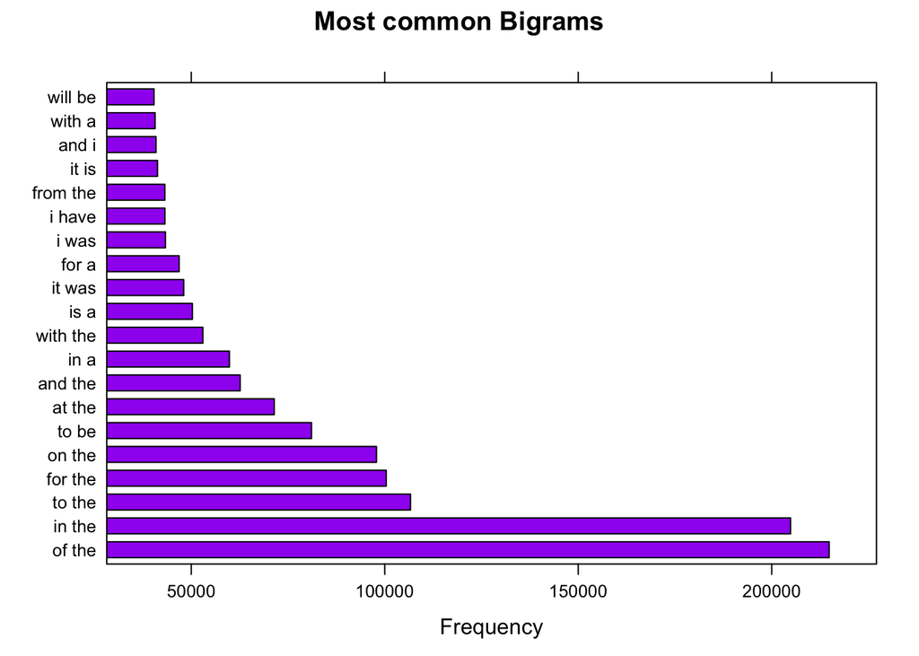

```r
library(lattice)
library(tm)
load("bigram.RData")
frequency <- rowSums(x = as.matrix(bigram))
order <- order(... = frequency, decreasing = TRUE)
barchart(frequency[head(order, 20)], col=("purple"), xlab="Frequency", main="Most common Bigrams")
```

- The most common trigrams are:

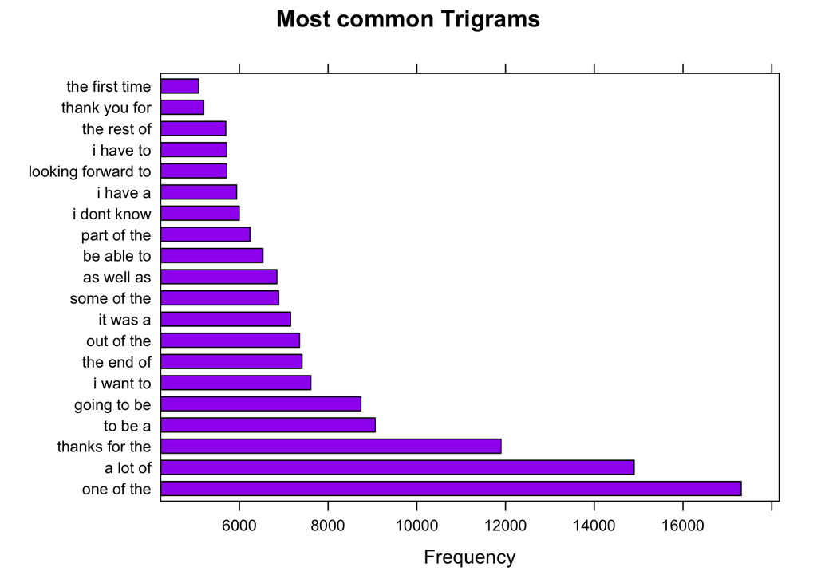

```r
load("trigram.RData")
frequency <- rowSums(x = as.matrix(trigram))
order <- order(... = frequency, decreasing = TRUE)
barchart(frequency[head(order, 20)], col=("purple"), xlab="Frequency", main="Most common Trigrams")
```

- The most common tetragrams are:

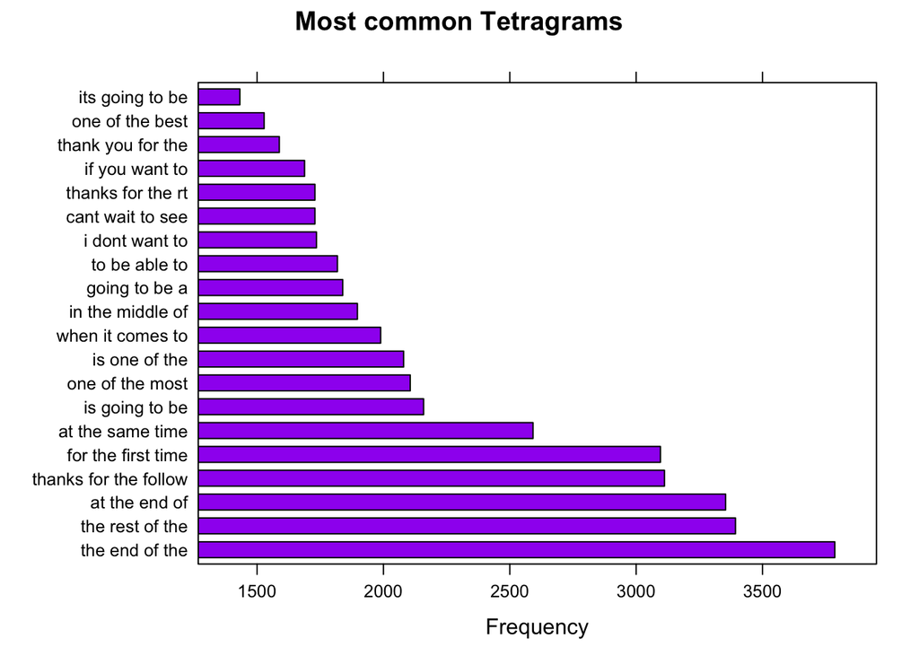

```r
load("tetragram.RData")
frequency <- rowSums(x = as.matrix(tetragram))
order <- order(... = frequency, decreasing = TRUE)
barchart(frequency[head(order, 20)], col=("purple"), xlab="Frequency", main="Most common Tetragrams")
```

## Building the Shiny App

- The next step would involve building a model that will predict words based on the n-Grams created above. This would involve creating markov chains or similar to predict the next words.
- We might need to go back and work on the model if the result aren’t good enough, tweaking the cleaning steps, and perhaps removing stopwords.
- Finally, we need to tie all this together into a Shiny App that will let us predict words based on inputs.